# The Battle of the Neighborhoods - Week 2

__The Battle of the Neighborhoods - Week 2__

## LEUNG CHUNG MING

__Introduction:__

This report is for those planning to start a new restaurant. Provide as many suggestions as possible about the factors to consider when starting a new business.

__Business problem:__

This report begins with a business issue. Focus on the issues you may encounter when opening a new restaurant. There are many factors to consider when setting up a small or large business. For example, if an investor wants to open a fusion Chinese restaurant, the first thing to be determined is the location of the new restaurant. Site selection, vegetable market, school, industrial zone commercial street, this type of shop has a large population of mobile population? If you target the target group to the middle class with high consumption power, you can choose the commercial street route, Choose from high-end department stores, high-end pedestrian streets, or famous commercial streets. Or a community-based route, the restaurant will be opened in the middle and high-end residential areas and scenic spots. This kind of site selection is quiet and heavy.

__Discussion:__

Let's discuss the problem statement mentioned above. First, investors want to open a fusion Chinese restaurant in Manhattan, New York City. New York City Manhattan Wall Street is the financial center of the United States because real estate is very expensive. Now she needs to figure out how many restaurants are in the A, B, C and other neighborhoods. If there are more than two restaurants in the vicinity, then a new restaurant with the same food in the community will be a big risk. Considering the rents in the neighborhood, choosing a place with fewer or no restaurants would be a good choice. This is the effect of reducing profits in order to reduce competition in the industry. Need to find a place that many people visit frequently so that the investor's business is above average. Downtown, cinemas, shopping centers and gas stations will help the restaurant's business operations. Restaurant ratings, customer sign-in may help determine the location of the crowd. I also recommend that the restaurant develop an executive business package to attract executives from the district to come to the business.

__Data Description:__

```python
import pandas as pd
import matplotlib
import numpy as np
import math
import matplotlib.pyplot as plt
from matplotlib.ticker import MaxNLocator
from collections import namedtuple

df_restaurant = pd.read_csv('https://data.cityofnewyork.us/api/views/43nn-pn8j/rows.csv?accessType=DOWNLOAD')
```

```python
df_Mana = df_restaurant.loc[df_restaurant['BORO'] == 'Manhattan']

df_Mana.head()
```

|  | CAMIS | DBA | BORO | BUILDING | STREET | ZIPCODE | PHONE | CUISINE DESCRIPTION | INSPECTION DATE | ACTION | ... | RECORD DATE | INSPECTION TYPE | Latitude | Longitude | Community Board | Council District | Census Tract | BIN | BBL | NTA |
| --- | --- | --- | --- | --- | --- | --- | --- | --- | --- | --- | --- | --- | --- | --- | --- | --- | --- | --- | --- | --- | --- |
| 1 | 50077581 | L'ADRESSE AMERICAN BISTRO | Manhattan | 5 | BRYANT PARK | 10018.0 | 2122212510 | French | 08/08/2019 | Violations were cited in the following area(s). | ... | 09/15/2019 | Cycle Inspection / Initial Inspection | 40.753937 | -73.985949 | 105.0 | 4.0 | 11300.0 | 1022565.0 | 1.009930e+09 | MN17 |
| 3 | 50048097 | MEE'S NOODLE | Manhattan | 930 | 2ND AVE | 10022.0 | 2128880027 | Chinese | 09/15/2016 | Violations were cited in the following area(s). | ... | 09/15/2019 | Cycle Inspection / Re-inspection | 40.754480 | -73.968793 | 106.0 | 4.0 | 9800.0 | 1039466.0 | 1.013420e+09 | MN19 |
| 4 | 50009874 | EL PALACIO SEAFOOD MARKET | Manhattan | 1049 | SAINT NICHOLAS AVE | 10032.0 | 2125680770 | Seafood | 07/22/2019 | Violations were cited in the following area(s). | ... | 09/15/2019 | Cycle Inspection / Initial Inspection | 40.836471 | -73.940031 | 112.0 | 7.0 | 24500.0 | 1062949.0 | 1.021220e+09 | MN36 |
| 7 | 41586126 | NEW SPRING BOY CHINESE RESTAURANT | Manhattan | 81 | ALLEN STREET | 10002.0 | 2126251921 | Chinese | 01/18/2019 | Violations were cited in the following area(s). | ... | 09/15/2019 | Cycle Inspection / Re-inspection | 40.717929 | -73.991039 | 103.0 | 1.0 | 1800.0 | 1005438.0 | 1.004130e+09 | MN27 |
| 8 | 41589545 | ZANNY'S CAFE | Manhattan | 975 | COLUMBUS AVENUE | 10025.0 | 2123166849 | American | 07/25/2016 | Violations were cited in the following area(s). | ... | 09/15/2019 | Cycle Inspection / Initial Inspection | 40.800389 | -73.962010 | 107.0 | 7.0 | 19300.0 | 1055704.0 | 1.018430e+09 | MN09 |

5 rows × 26 columns

```python
df_ma_cd=df_Mana['CUISINE DESCRIPTION'].value_counts().to_frame()
df_ma_cd
```

|  | CUISINE DESCRIPTION |
| --- | --- |
| American | 43048 |
| Chinese | 10485 |
| Café/Coffee/Tea | 10016 |
| Italian | 9339 |
| Japanese | 7721 |
| Pizza | 5297 |
| Mexican | 5137 |
| Latin (Cuban, Dominican, Puerto Rican, South & Central American) | 4001 |
| Bakery | 3723 |
| French | 3560 |
| Delicatessen | 3023 |
| Indian | 2889 |
| Asian | 2709 |
| Thai | 2644 |
| Pizza/Italian | 2305 |
| Spanish | 2224 |
| Irish | 2157 |
| Mediterranean | 2145 |
| Juice, Smoothies, Fruit Salads | 2065 |
| Korean | 1890 |
| Sandwiches | 1877 |
| Chicken | 1619 |
| Donuts | 1439 |
| Sandwiches/Salads/Mixed Buffet | 1423 |
| Seafood | 1340 |
| Hamburgers | 1266 |
| Jewish/Kosher | 1195 |
| Bagels/Pretzels | 1080 |
| Vegetarian | 1061 |
| Other | 997 |
| ... | ... |
| Soul Food | 261 |
| Chinese/Cuban | 231 |
| Brazilian | 186 |
| Ethiopian | 181 |
| English | 181 |
| Filipino | 171 |
| German | 166 |
| Armenian | 162 |
| Moroccan | 152 |
| Pakistani | 145 |
| Bangladeshi | 131 |
| Hotdogs/Pretzels | 118 |
| Russian | 114 |
| Hotdogs | 102 |
| Californian | 76 |
| Scandinavian | 62 |
| Polish | 55 |
| Afghan | 47 |
| Creole | 43 |
| Iranian | 43 |
| Egyptian | 41 |
| Not Listed/Not Applicable | 39 |
| Fruits/Vegetables | 37 |
| Soups | 36 |
| Indonesian | 33 |
| Portuguese | 27 |
| Pancakes/Waffles | 25 |
| Southwestern | 22 |
| Nuts/Confectionary | 9 |
| Basque | 7 |

80 rows × 1 columns

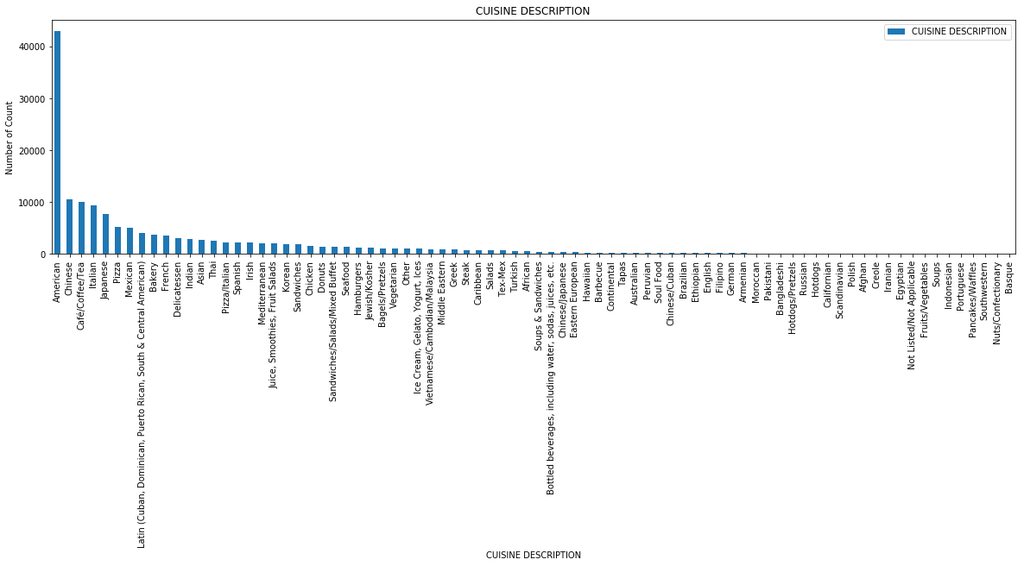

```python
df_ma_cd.plot(kind='bar', figsize=(20, 5))

plt.title('CUISINE DESCRIPTION') # add a title to the histogram
plt.ylabel('Number of Count') # add y-label
plt.xlabel('CUISINE DESCRIPTION') # add x-label

plt.show()
```

```python
df_ma_st=df_Mana['STREET'].value_counts().to_frame()
df_ma_st
```

|  | STREET |
| --- | --- |
| BROADWAY | 9204 |
| 2ND AVE | 3678 |
| 1ST AVE | 2909 |
| 2 AVENUE | 2875 |
| 3RD AVE | 2874 |
| 3 AVENUE | 2300 |
| LEXINGTON AVE | 2266 |
| 1 AVENUE | 2196 |
| 9TH AVE | 2155 |
| LEXINGTON AVENUE | 2148 |
| AMSTERDAM AVE | 2130 |
| 9 AVENUE | 2045 |
| AMSTERDAM AVENUE | 2025 |
| 8TH AVE | 1928 |
| 8 AVENUE | 1703 |
| 7 AVENUE | 1303 |
| MADISON AVE | 1032 |
| MADISON AVENUE | 1030 |
| AVENUE OF THE AMERICAS | 998 |
| 7TH AVE | 990 |
| AVENUE A | 957 |
| 10 AVENUE | 905 |
| 5TH AVE | 888 |
| MOTT STREET | 887 |
| COLUMBUS AVE | 882 |
| BOWERY | 839 |
| WEST 46 STREET | 801 |
| SAINT NICHOLAS AVE | 797 |
| 10TH AVE | 795 |
| COLUMBUS AVENUE | 765 |
| ... | ... |
| CEDAR ST | 2 |
| S 8 avenue | 2 |
| PLEASANT AVE | 2 |
| STATE ST | 2 |
| TIMES SQUAREKIOSK BTW 43-44 ST | 2 |
| E 67TH ST | 2 |
| HIGH LINE PARK WEST 15TH STREET | 1 |
| BROADWAY BTWN 42ND-43RD ST | 1 |
| WASHINGTON SQ W | 1 |
| E 120TH ST | 1 |
| CLAREMONT AVE | 1 |
| CLAYTON RD | 1 |
| HIGHLINE PARK WEST 15TH STREET | 1 |
| 7TH AVE SOUTH | 1 |
| GRESHAM ROAD | 1 |
| BROADWAY BETWEEN 42ND & 43RD ST | 1 |
| PENN STATION A | 1 |
| FOLEY SQ | 1 |
| TIMES SQUARE BTWN 42RD AND 44TH ST | 1 |
| BROADWAY PLAZA BET 42ND 43RD ST | 1 |
| HIGH LINE PK WEST 22ND ST | 1 |
| W 167TH ST | 1 |
| FORT WASHINGTON AVE | 1 |
| high line park west 30th street | 1 |
| CENTRAL RD | 1 |
| PACE PLZ | 1 |
| BROADWAY Plaza BTWN 46-47 | 1 |
| 7TH AVE @ 56TH STREET | 1 |
| PERRY ST | 1 |
| E 75TH ST | 1 |

1214 rows × 1 columns

[figure not shown]

```python
df_ma_st.plot(kind='barh', figsize=(20, 200))

plt.title('Restaurant in Steet') # add a title to the histogram
plt.ylabel('Steet') # add y-label
plt.xlabel('Number of Count') # add x-label

plt.show()
```

```python
from pandas.io.json import json_normalize
!pip install folium==0.5.0
import folium
from geopy.geocoders import Nominatim
import requests
import json
import pandas as pd
```

```python
# Define Foursquare Credentials and Version
CLIENT_ID = 'HRMBKZUASN1NWO005IQK4TGG15UVEY5GCLJCYXHXW0VDP00K' # your Foursquare ID
CLIENT_SECRET = 'JSXFO23NR2OMICQSZRFQYDAZG1GMNRALXXACAFVNF5CGAM4C' # your Foursquare Secret
VERSION = '20180604'
limit = 100
print('Your credentails:')
print('CLIENT_ID:'+ CLIENT_ID)
print('CLIENT_SECRET:'+ CLIENT_SECRET)
```

```
Your credentails:
CLIENT_ID:HRMBKZUASN1NWO005IQK4TGG15UVEY5GCLJCYXHXW0VDP00K
CLIENT_SECRET:JSXFO23NR2OMICQSZRFQYDAZG1GMNRALXXACAFVNF5CGAM4C
```

```python
neighborhood_latitude=40.7068769
neighborhood_longitude=-74.0112656
```

```python
LIMIT = 200 # limit of number of venues returned by Foursquare API
radius = 400 # define radius

# create URL
url = 'https://api.foursquare.com/v2/venues/explore?&client_id={}&client_secret={}&v={}&ll={},{}&radius={}&limit={}'.format(
    CLIENT_ID,
    CLIENT_SECRET,
    VERSION,
    neighborhood_latitude,
    neighborhood_longitude,
    radius,
    LIMIT)
url # display URL
```

```
'https://api.foursquare.com/v2/venues/explore?&client_id=HRMBKZUASN1NWO005IQK4TGG15UVEY5GCLJCYXHXW0VDP00K&client_secret=JSXFO23NR2OMICQSZRFQYDAZG1GMNRALXXACAFVNF5CGAM4C&v=20180604&ll=40.7068769,-74.0112656&radius=400&limit=200'
```

```python
results = requests.get(url).json()
#results
```

```python
# function that extracts the category of the venue
def get_category_type(row):
    try:
        categories_list = row['categories']
    except:
        categories_list = row['venue.categories']

    if len(categories_list) == 0:
        return None
    else:
        return categories_list[0]['name']
```

```python
venues = results['response']['groups'][0]['items']

SGnearby_venues = json_normalize(venues) # flatten JSON

# filter columns
filtered_columns = ['venue.name', 'venue.categories', 'venue.location.lat', 'venue.location.lng']
SGnearby_venues =SGnearby_venues.loc[:, filtered_columns]

# filter the category for each row
SGnearby_venues['venue.categories'] = SGnearby_venues.apply(get_category_type, axis=1)

# clean columns
SGnearby_venues.columns = [col.split(".")[-1] for col in SGnearby_venues.columns]

SGnearby_venues
```

|  | name | categories | lat | lng |
| --- | --- | --- | --- | --- |
| 0 | Manhatta | New American Restaurant | 40.707654 | -74.009138 |
| 1 | Physique 57 | Gym / Fitness Center | 40.706844 | -74.013014 |
| 2 | One Medical | Doctor's Office | 40.706204 | -74.011712 |
| 3 | Greenwich St Jewelers | Jewelry Store | 40.708004 | -74.012801 |
| 4 | Equinox Wall Street | Gym | 40.707273 | -74.010543 |
| 5 | Fearless Girl | Monument / Landmark | 40.706772 | -74.010963 |
| 6 | Bluestone Lane | Café | 40.706268 | -74.011687 |
| 7 | Neapolitan Express | Pizza Place | 40.706908 | -74.009685 |
| 8 | The Capital Grille | American Restaurant | 40.707903 | -74.010086 |
| 9 | Cipriani Wall Street | Event Space | 40.706038 | -74.009269 |
| 10 | Crunch - FiDi | Gym / Fitness Center | 40.708614 | -74.010013 |
| 11 | Delmonico's | Steakhouse | 40.705153 | -74.010551 |
| 12 | Sam's Falafel | Food Truck | 40.708744 | -74.011458 |
| 13 | Champs Gourmet Deli | Deli / Bodega | 40.706470 | -74.011559 |
| 14 | 9/11 Tribute Museum | Museum | 40.707995 | -74.013701 |
| 15 | Tiffany & Co. | Jewelry Store | 40.706525 | -74.010226 |
| 16 | Federal Hall National Memorial | Historic Site | 40.707120 | -74.010552 |
| 17 | Black Fox Coffee Co. | Coffee Shop | 40.706573 | -74.008155 |
| 18 | Luke's Lobster | Seafood Restaurant | 40.704488 | -74.010915 |
| 19 | William Beaver House | Event Space | 40.705217 | -74.010045 |
| 20 | Sophie's Cuban Cuisine | Cuban Restaurant | 40.705424 | -74.012299 |
| 21 | La Colombe Torrefaction | Coffee Shop | 40.705899 | -74.008421 |
| 22 | The Setai Spa Wall Street | Spa | 40.706131 | -74.011420 |
| 23 | sweetgreen | Salad Place | 40.705586 | -74.008382 |
| 24 | Rouge Tomate Cart | Food Truck | 40.707390 | -74.014345 |
| 25 | Hermès | Accessories Store | 40.706505 | -74.010993 |
| 26 | &pizza | Pizza Place | 40.706615 | -74.009943 |
| 27 | Crossfit Wall Street | Gym | 40.705544 | -74.012139 |
| 28 | Taim | Falafel Restaurant | 40.707727 | -74.008265 |
| 29 | Reserve Cut | Steakhouse | 40.706132 | -74.011354 |
| ... | ... | ... | ... | ... |
| 70 | AKA Wall Street | Hotel | 40.708030 | -74.007850 |
| 71 | Chipotle Mexican Grill | Mexican Restaurant | 40.704888 | -74.012846 |
| 72 | Black Fox | Coffee Shop | 40.703968 | -74.011160 |
| 73 | Il Gelato @ Eataly | Ice Cream Shop | 40.709869 | -74.011686 |
| 74 | Dig Inn | American Restaurant | 40.706106 | -74.007290 |
| 75 | Gregorys Coffee | Coffee Shop | 40.706110 | -74.012850 |
| 76 | Periscope Coffee On Pearl Street | Food Truck | 40.704691 | -74.009301 |
| 77 | For Five Coffee Roasters | Coffee Shop | 40.709554 | -74.010576 |
| 78 | La Pasticceria di Eataly Downtown | Bakery | 40.709890 | -74.011598 |
| 79 | The Lovelace Cocktail & Gin Bar | Cocktail Bar | 40.703585 | -74.010600 |
| 80 | Zuccotti Park | Park | 40.709259 | -74.011245 |
| 81 | Fraunces Tavern | Bar | 40.703526 | -74.011395 |
| 82 | Louise Nevelson Plaza | Park | 40.707680 | -74.007965 |
| 83 | Biryani House (Cart) | Food Truck | 40.705050 | -74.012313 |
| 84 | George's New York | Diner | 40.707895 | -74.013500 |
| 85 | The Cauldron | Bar | 40.704354 | -74.010356 |
| 86 | Juice Press | Juice Bar | 40.707281 | -74.010204 |
| 87 | Pure Liquid Wine & Spirits | Wine Shop | 40.710083 | -74.011791 |
| 88 | Vintry Wine & Whiskey | Wine Bar | 40.704419 | -74.010257 |
| 89 | JOE & THE JUICE | Juice Bar | 40.705570 | -74.008160 |
| 90 | LOFT | Women's Store | 40.704695 | -74.013031 |
| 91 | O'Hara's Restaurant & Pub | Pub | 40.709894 | -74.012836 |
| 92 | Bluestone Lane | Café | 40.704599 | -74.008748 |
| 93 | Blue Park Kitchen | American Restaurant | 40.706503 | -74.008077 |
| 94 | SoulCycle FiDi | Cycle Studio | 40.706904 | -74.006717 |
| 95 | Nish Nush | Falafel Restaurant | 40.709418 | -74.008056 |
| 96 | Residence Inn by Marriott New York Downtown Ma... | Hotel | 40.709605 | -74.009827 |
| 97 | Just Salad | Salad Place | 40.703539 | -74.011627 |
| 98 | Bobby Van's | Steakhouse | 40.706291 | -74.011038 |
| 99 | Giardino D'oro | Italian Restaurant | 40.707548 | -74.007249 |

100 rows × 4 columns

```python
# create map of Singapore place  using latitude and longitude values
map_sg = folium.Map(location=[40.7068769,-74.0112656], zoom_start=16)

# add markers to map
for lat, lng, label in zip(SGnearby_venues['lat'], SGnearby_venues['lng'], SGnearby_venues['name']):
    label = folium.Popup(label, parse_html=True)
    folium.RegularPolygonMarker(
        [lat, lng],
        number_of_sides=16,
        radius=5,
        popup=label,
        color='blue',
        fill_color='#0f0f0f',
        fill_opacity=0.7,
    ).add_to(map_sg)

map_sg
```

[interactive chart not shown]

```python
import numpy as np

name='16 Maiden Ln','141 Duane St','124 Chambers St','77 Warren St','291 Broadway','45 Nassau St','41 Nassau St','Equitable Building','125 Maiden Ln'
Area='Financial District, New York City, NY','Tribeca, New York City, NY','Tribeca, New York City, NY','Tribeca, New York City, NY','Financial District, New York City, NY','Financial District, New York City, NY','120 Broadway, New York, NY,','Financial District, New York City, NY'
Level='Floor Ground','Floor Ground','Space','Space','Space','Floor Lower Level','Floor Ground','Space','Space'
sqft=1200,3300,4800,5050,1750,6050,1650,16980,5350
lat=40.70927,40.71657,40.71516,40.71503,40.71492,40.70887,40.70879,40.70851,40.70672
lng=-74.01150,-74.00990,-74.01100,-74.01260,-74.00830,-74.01160,-74.01160,-74.01310,-74.00870


rents=list(zip(name, Area, Level, sqft, lat, lng))

df_rents = pd.DataFrame(rents, columns = ['name', 'Area', 'Level', 'sqft', 'lat', 'lng'])

df_rents
```

|  | name | Area | Level | sqft | lat | lng |
| --- | --- | --- | --- | --- | --- | --- |
| 0 | 16 Maiden Ln | Financial District, New York City, NY | Floor Ground | 1200 | 40.70927 | -74.0115 |
| 1 | 141 Duane St | Tribeca, New York City, NY | Floor Ground | 3300 | 40.71657 | -74.0099 |
| 2 | 124 Chambers St | Tribeca, New York City, NY | Space | 4800 | 40.71516 | -74.0110 |
| 3 | 77 Warren St | Tribeca, New York City, NY | Space | 5050 | 40.71503 | -74.0126 |
| 4 | 291 Broadway | Financial District, New York City, NY | Space | 1750 | 40.71492 | -74.0083 |
| 5 | 45 Nassau St | Financial District, New York City, NY | Floor Lower Level | 6050 | 40.70887 | -74.0116 |
| 6 | 41 Nassau St | 120 Broadway, New York, NY, | Floor Ground | 1650 | 40.70879 | -74.0116 |
| 7 | Equitable Building | Financial District, New York City, NY | Space | 16980 | 40.70851 | -74.0131 |

```python
from folium import plugins

map_rents = folium.Map(location=[40.7118769,-74.0112656], zoom_start=16)

# add markers to map
for lat, lng, label in zip(df_rents['lat'], df_rents['lng'], df_rents['name']):
    label = folium.Popup(label, parse_html=True)
    folium.RegularPolygonMarker(
        [lat, lng],
        number_of_sides=16,
        radius=5,
        popup=label,
        color='red',
        fill_color='#0f0f0f',
        fill_opacity=0.7,
    ).add_to(map_rents)

for lat, lng, label in zip(SGnearby_venues['lat'], SGnearby_venues['lng'], SGnearby_venues['name']):
    label = folium.Popup(label, parse_html=True)
    folium.RegularPolygonMarker(
        [lat, lng],
        number_of_sides=16,
        radius=5,
        popup=label,
        color='blue',
        fill_color='#0f0f0f',
        fill_opacity=0.7,
    ).add_to(map_rents)

map_rents
```

[interactive chart not shown]

__Methodology:__

In this case, we finding much open fusion Chinese restaurant in Manhattan, New York City in Manhattan, Nw York City of area.

In this project, we will direct our efforts on detecting areas of Manhattan, New York City that have a Chinese restaurant. We will limit our analysis to area 400m.

In the first step we have collected the required data: location and type (category) of every restaurant within 400m from Manhattan (Wall Street). We have also identified the restaurant (according to Foursquare categorization).

The second step in our analysis will be calculation and exploration near Wall Street can open restaurant rental market and focus our attention on those areas.

__Analysis:__

```python
df_rents.drop(df_rents.index[[1,2,3,4]])
```

|  | name | Area | Level | sqft | lat | lng |
| --- | --- | --- | --- | --- | --- | --- |
| 0 | 16 Maiden Ln | Financial District, New York City, NY | Floor Ground | 1200 | 40.70927 | -74.0115 |
| 5 | 45 Nassau St | Financial District, New York City, NY | Floor Lower Level | 6050 | 40.70887 | -74.0116 |
| 6 | 41 Nassau St | 120 Broadway, New York, NY, | Floor Ground | 1650 | 40.70879 | -74.0116 |
| 7 | Equitable Building | Financial District, New York City, NY | Space | 16980 | 40.70851 | -74.0131 |

Let's perform some basic interpretive data analysis and get some extra information from the raw data. First let us calculate the number of restaurants in the Manhattan, New York City area to get results for more than 15,000 restaurants. We create a map and try to extract some meaningful information from it. In addition, let us display the 100 places in Manhattan, New York City on the map and mark them with blue dots. Our investors prefer to work for Wall Street, mainly for commercial dinners, so we are looking for a rental market near restaurants. We managed to find 8 places open in the rental market. We created a map and tried to Extract some meaningful information. And marked with a red dot. Let's perform some basic explanatory data analysis. We removed the distance from Wall Street = 141 Duane St, 124 Chambers St, 77 Warren St, 291 Broadway. After excluding the unwanted selections, and from the information in the original data let us know the area of these places such as : 16 Maiden Ln = 1200 sq ft , 45 Nassau St = 6050 sq ft, 41 Nassau St = 1650 sq ft , Equitable Building = 16980 sq ft. Finally, we consider that our investors are the main factor in commercial dinner service. Too big a supply is not available. So Equitable Building is not going to choose. Too few places to supply can not meet the needs of the restaurant. So 16 Maiden L and 41 Nassau St are not going to choose. We are able to find suitable investors in neighboring Wall Street, Manhattan, New York City under the constraints of market supply. The result is 45 Nassau St = 6050 sq ft

```python
df_rents.drop(df_rents.index[[0,1,2,3,4,6,7]])
```

|  | name | Area | Level | sqft | lat | lng |
| --- | --- | --- | --- | --- | --- | --- |
| 5 | 45 Nassau St | Financial District, New York City, NY | Floor Lower Level | 6050 | 40.70887 | -74.0116 |